# How miRNA - target distance influences their regulation?

2021-05-28

## Questions to answer

- What are the specificities of the miRNA - target interaction network? How can be it modelled using networks? - Luca
- Does the chromosomal localization of the target gene affect its miRNA regulation? - Sophie
- What is the connection between the function of the regulated target genes and the miRNAs regulating them? - Ági
- How does the distance between the miRNA gene and the target gene affect their regulation? - Benedek

## Introduction - miRNAs

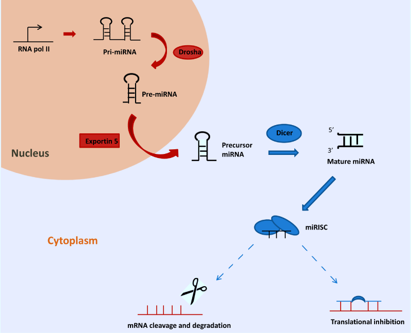

## Dataset

- Human miRNA - target interaction databasePlotnikova, Olga, Ancha Baranova, and Mikhail Skoblov. “Comprehensive Analysis of Human microRNA–mRNA Interactome” Frontiers in Genetics 10 (2019):933. https://doi.org/10.3389/fgene.2019.00933 downloaded from Exp-miBR (in `.tsv` format): experimentally confirmed miRNA binding regions and their features included too
- Column names: `CHROM`, `start_Ref38`, `end_Ref38`, `length`, `STRAND`, `NDATASET`, `DATASET`, `NLINES`, `LINES`, `MIRNA`, `REGION`, `GENES`
- 46,740 rows, many `NA` values, miRNA IDs and target gene IDs often in one row, separated by commas

## Visualize the network

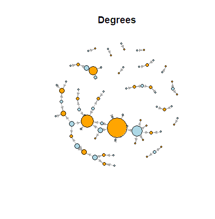

## Cytoscape visualization with RCy3

```r
library("RCy3")

# Run visualisation if cytoscape is open
if(continue){
  createNetworkFromDataFrames(nodes2, edges=net2[,1:2], title="exonic network")
  edges <- net2 %>%
    mutate(key=paste(source, "(interacts with)", target))
  print(edges)
  loadTableData(edges[,3:4], data.key.column = 'key', table = 'edge')

  # Colour by Betweenness centrality if data exists in network
  if (bet){
    setNodeColorMapping("betweenness_centrality",mapping.type="c", network="exonic network")
  }

  # Save cys file
  saveSession(filename = file.path("output/exonic_network.cys"))
}
```

## Cytoscape visualization with RCy3

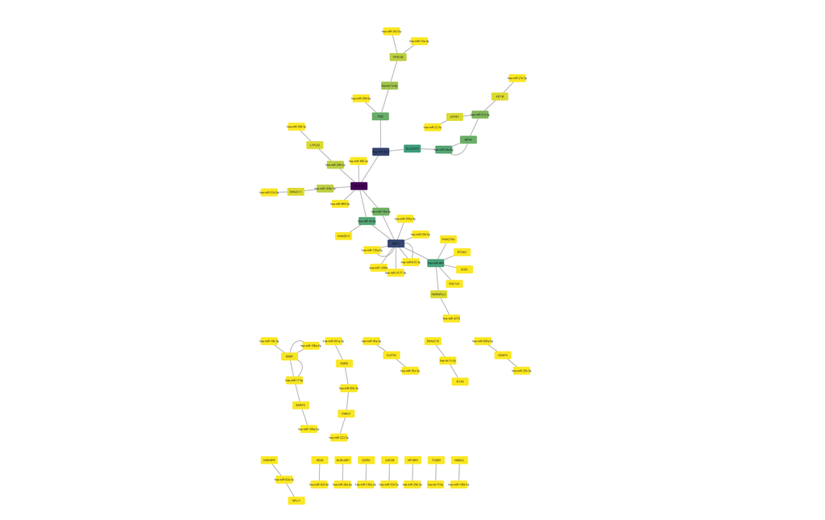

## Working with networks/graphs - igraph library

```r
library("igraph")

# Create graph object from edge list:
mirna_graph <- graph_from_edgelist(as.matrix(mirna_target_data[,1:2]),
                                   directed = F)

# Generate random graph with the same properties:
random_graph <- sample_gnm(n=length(c(mirna_target_data$MIRNA,   # number of vertices
                                      mirna_target_data$GENES)),
                           m = nrow(mirna_target_data))          # number of edges

# Get the degree distribution data:
random_degree_dist <- data.frame(k=as.numeric(degree(random_graph))) %>%
  group_by(k) %>%                 # edge number
  summarize(freq=n()) %>%
  filter(k!=0) %>%
  mutate(freq=freq/sum(freq)) %>% # calculate frequency (0-1)
  as.data.frame()

mirna_degree_dist <- mirna_target_data %>%
  group_by(MIRNA) %>%
  summarize(k=n()) %>%
  group_by(k) %>%
  summarize(freq=n()) %>%
  mutate(freq=freq/sum(freq)) %>%
  as.data.frame()
```

## Visualize degree distribution - Plot

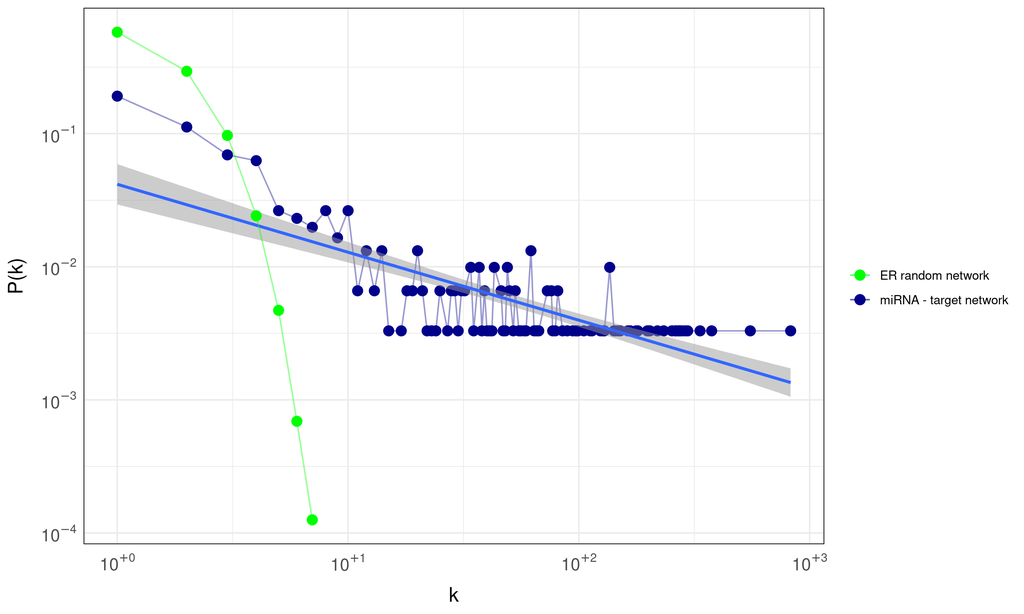

## Chromosome length versus number of miRNAs - Arrange text annotation automatically

```r
# Plot the length of the chromosome vs. number of miRNAs:
cor_plot <- ggplot(chr_info, aes(x=V2, y=count,label = V1))+
  geom_point(size=3)+
  ggrepel::geom_text_repel()+
  theme_minimal() +
  theme(panel.border = element_rect(color = "black", fill = NA),
        axis.text.x = element_text(size=12, hjust = 0.5, vjust = 0.5, angle=0),
        axis.title.x = element_text(size = 14, margin = margin(t = 10, r = 0, b = 0, l = 0)),
        axis.title.y = element_text(size = 14, margin = margin(t = 0, r = 10, b = 0, l = 0)),
        axis.text.y = element_text(size = 12),
        legend.position="none")+
  xlab("Chromosome length (bp)")+
  ylab("Number of miRNAs")
```

## Chromosome length versus number of miRNAs plot

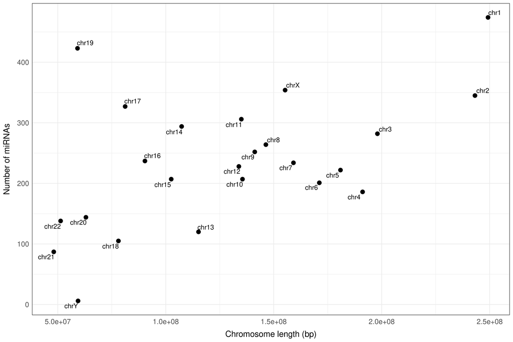

## Randomization and heatmap

1. data cleaning
2. randomizing the target gene chromosome localizations
3. calculating the occurance

```r
        (occurence <- (table(miRNA_data_4$MIRNA,miRNA_data_4$CHROM)))
```

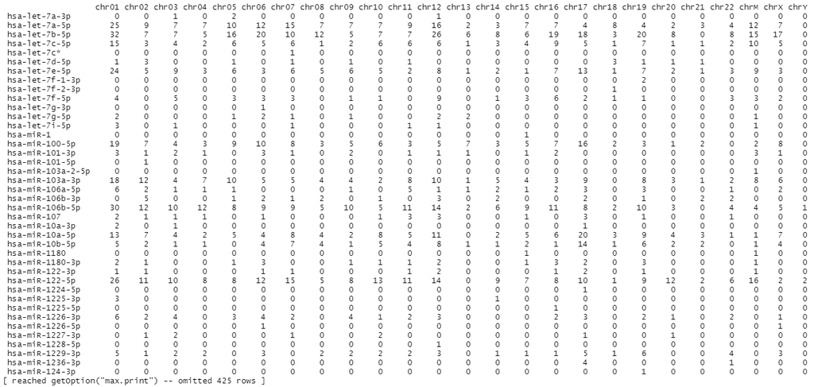

## Randomization and heatmap

1. data cleaning
2. randomizing the target gene chromosome localizations
3. calculating the occurance
4. visualizing the results using heatmap

```r
# original 1. plot
        png("original1.png", width = 700, height = 700)
        heatmap(occurence[,],
                scale="row",
                Rowv=TRUE,Colv=NA,
                xlab="Chromosome",ylab="miRNA",
                main="The number of miRNA target genes in each chromosome",
                margins=c(4,8))
        dev.off()
```

## Randomization and heatmap

1. data cleaning
2. randomizing the target gene chromosome localizations
3. calculating the occurance
4. visualizing the results using heatmap or ggplot

```r
# original 2. plot
        original2 <- ggplot(occurence_df[,],aes(Var2,Var1,fill=Freq))+
                labs(x="Chromosome",
                     y="miRNA",
                     title="The occurence of target genes for miRNAs")+
                geom_tile()+
                theme(axis.title.x = element_text(size = 14),
                      axis.text.x = element_text(size = 12),
                      axis.title.y = element_text(size = 14),
                      axis.text.y = element_blank(),
                      legend.title = element_text(size = 14),
                      legend.text = element_text(size = 12),
                      plot.title = element_text(size = 20))+
                scale_fill_gradient(name="Target \nnumber",
                                    low="white", high="darkblue",
                                    limits=c(0,100))
        ggsave("C:/Users/Lenovo/Documents/R/original2.png",
               original2, units = "in", width = 14, height = 10)
```

```r
# original 3. plot
        original3 <- ggplot(target100,aes(Var2,Var1,fill=percent))+
                labs(x="Chromosome",
                     y="miRNA",
                     title="The occurence of target genes for miRNAs, \nwhich have more than 100 targets")+
                geom_tile()+
                theme(axis.title.x = element_text(size = 14),
                      axis.text.x = element_text(size = 12),
                      axis.title.y = element_text(size = 14),
                      axis.text.y = element_text(size = 12),
                      legend.title = element_text(size = 14),
                      legend.text = element_text(size = 12),
                      plot.title = element_text(size = 20))+
                scale_fill_gradient(name="Target \nfrequency",
                                    low="white", high="darkblue",
                                    limits=c(0,0.2))
        ggsave("C:/Users/Lenovo/Documents/R/original3.png",
               original3, units = "in", width = 15, height = 10)

# random 1. plot
        png("random1.png", width = 700, height = 700)
        heatmap(occurence_random[],
                scale="row",
                Rowv=TRUE,Colv=NA,
                xlab="Chromosome",ylab="miRNA",
                main="The number of miRNA target genes in each chromosome \n after randomization",
                margins=c(4,8))
        # Heatmap(occurence_random[],
        #         name="The",
        #         cluster_columns = FALSE,
        #         clustering_method_rows ="complete",
        #         show_row_names = FALSE,
        #         row_title="miRNA",row_title_gp=gpar(fontsize = 14),
        #         column_title="Chromosome",column_title_gp=gpar(fontsize = 14))
        dev.off()

# random 2. plot
        random2 <- ggplot(occurence_random_df[,],aes(Var2,Var1,fill=Freq))+
                labs(x="Chromosome",
                     y="miRNA",
                     title="After randomization, the occurence of target genes for miRNAs")+
                geom_tile()+
                theme(axis.title.x = element_text(size = 14),
                      axis.text.x = element_text(size = 12),
                      axis.title.y = element_text(size = 14),
                      axis.text.y = element_blank(),
                      legend.title = element_text(size = 14),
                      legend.text = element_text(size = 12),
                      plot.title = element_text(size = 20))+
                scale_fill_gradient(name="Target \nnumber",
                                    low="white", high="darkblue",
                                    limits=c(0,100))
        ggsave("C:/Users/Lenovo/Documents/R/random2.png",
               random2, units = "in", width = 14, height = 10)

# random 3. plot
        random3 <- ggplot(target100_rand,aes(Var2,Var1,fill=percent))+
                labs(x="Chromosome",
                     y="miRNA",
                     title="After randomization, the occurence of target genes for miRNAs, \nwhich have more than 100 targets")+
                geom_tile()+
                theme(axis.title.x = element_text(size = 14),
                      axis.text.x = element_text(size = 12),
                      axis.title.y = element_text(size = 14),
                      axis.text.y = element_text(size = 12),
                      legend.title = element_text(size = 14),
                      legend.text = element_text(size = 12),
                      plot.title = element_text(size = 20))+
                scale_fill_gradient(name="Target \nfrequency",
                                    low="white", high="darkblue",
                                    limits=c(0,0.2))
        ggsave("C:/Users/Lenovo/Documents/R/random3.png",
               random3, units = "in", width = 15, height = 10)
```

## Original 1. plot

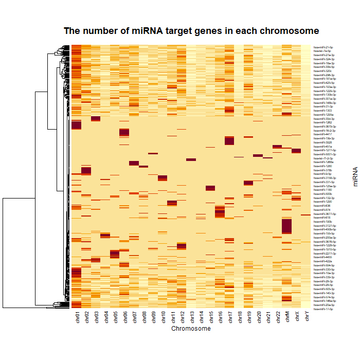

## Random 1. plot

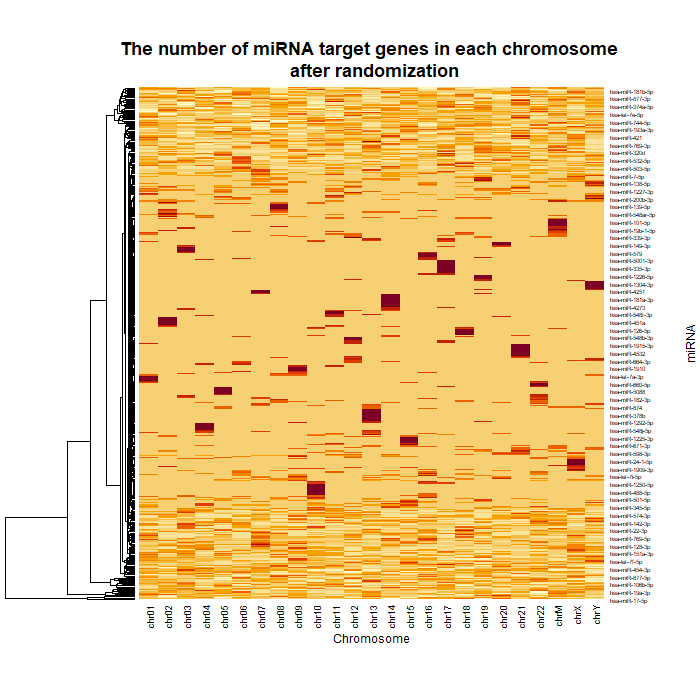

## Original 2. plot

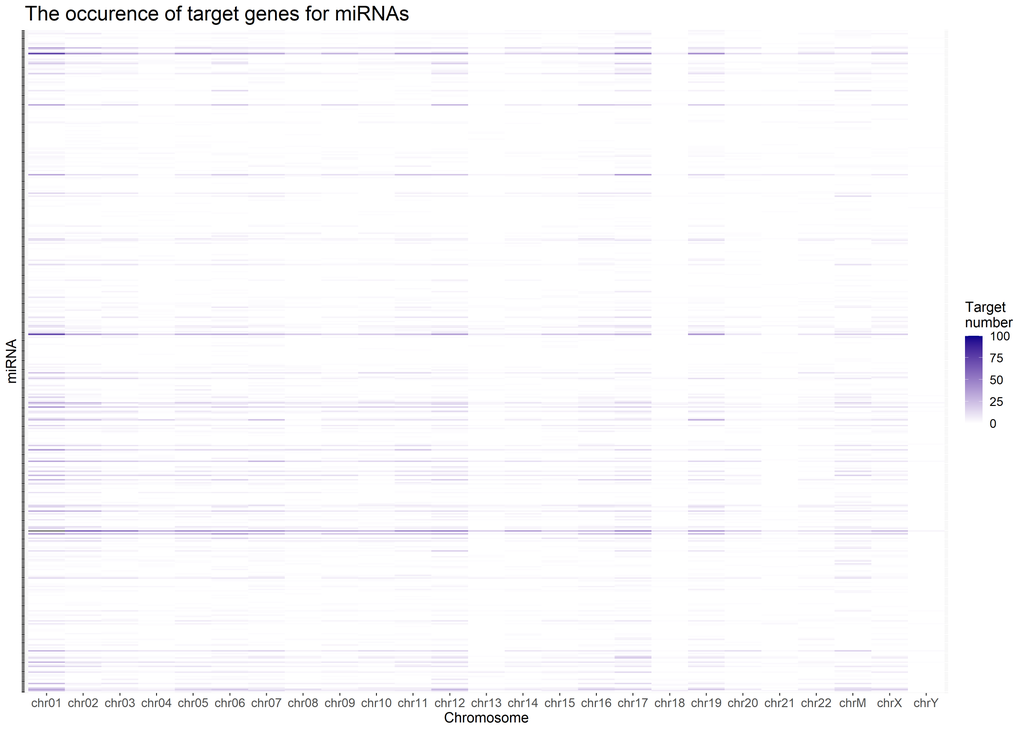

## Random 2. plot

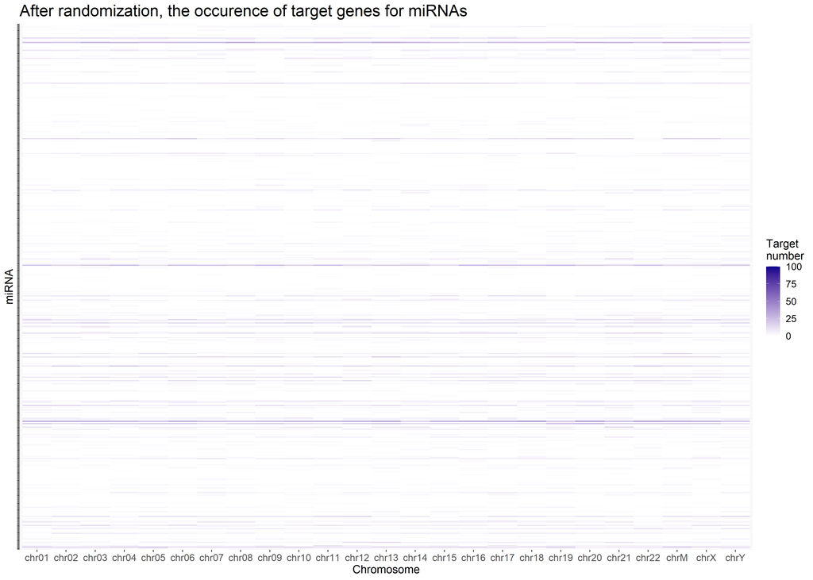

## Original 3. plot

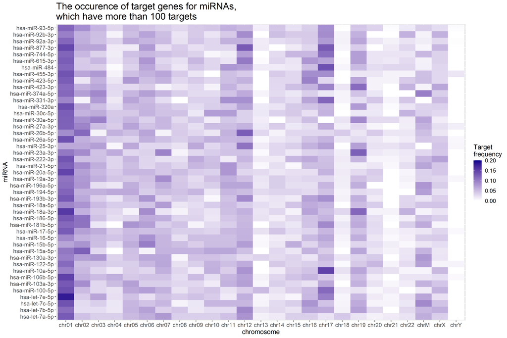

## Random 3. plot

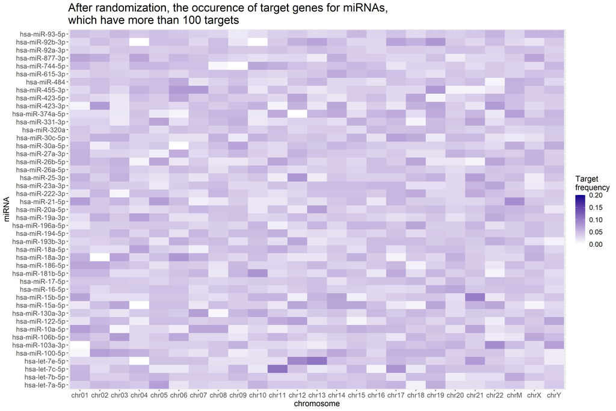

## GO Terms analysis

- Retrieving the gene ontology information of the genes based on ensemble gene identifiers
- biomaRt package

```r
###################################################################################
#               A GO Term analyses using the biomaRt package
###################################################################################

library("biomaRt")
library("GO.db")
setwd("D:/University/4_SEMESTER/R_advanced/miRNA_project")

# Load the data: -----
mirnas <- read.table("D:/University/4_SEMESTER/R_advanced/miRNA_project/mirna_targetgene_pairs.tsv", header = TRUE)
head(mirnas)

# data cleaning is needed to remove the NA values: ----
gene_ids <- na.omit(gene_ids)
head(gene_ids)

listMarts()
listDatasets(ensembl) # "hsapiens_gene_ensembl"
listDatasets(ensembl)$dataset # just ..._gene_ensembl datasets printed out
```

## GO Terms analysis

```r
# Choosing the ensembl mart and homo sapiens dataset:
ensembl = useMart("ensembl",dataset="hsapiens_gene_ensembl")
# Searching for filters (for the query which will be built)
filters = listFilters(ensembl)
head(filters)
# Check all the attributes to find those what can be important for now:
attributes = listAttributes(ensembl)
# Selected attributes:
# ensembl_gene_id - Gene stable ID
# chromosome_name - Chromosome/scaffold name
# external_gene_name - Gene name
# transcript_count - Transcript count
# go_id - GO term accession
# name_1006 - GO term name

# Query on all the gene ids:
GO_Terms <- getBM(attributes = c("ensembl_gene_id", "name_1006", "go_id",
                                 "external_gene_name", "transcript_count", "chromosome_name"),
                                filters = "ensembl_gene_id", values = gene_ids, mart = ensembl)

GO_Terms <- as.data.frame(GO_Terms)
write.table(GO_Terms, file = "GO_terms_output_2.csv", sep = "\t")
```

## Distribution of molecular functions on the chromosomes

- How are the molecular functions distributed on the chromosomes?

```r
library(tidyverse)
library(dplyr)
library(ggplot2)

GO_Terms <- read.table("D:/University/4_SEMESTER/R_advanced/miRNA_project/GO_terms_output_2.csv", header = TRUE)
head(GO_Terms)
filter_go_terms <- c("GO:0042632", "GO:0045727", "GO:0035195", "GO:0043410", "GO:0030336", "GO:0032869")
filtered_go_terms <- GO_Terms %>% filter(go_id %in% filter_go_terms)
head(filtered_go_terms)
chr_occurrences_df <- as.data.frame(table(filtered_go_terms$go_id, filtered_go_terms$chromosome_name))
chr_occurrences_df

selected_genes_plot <- ggplot(chr_occurrences_df, aes(x = Var2, y = Freq, fill = Var1))+
  geom_col()+
  theme_light()+
  labs(x = "Chromosomes",
       y = "Number of occurences of the function's genes on the crhomosomes",
       title = "Distribution of molecular functions on the chromosomes")
selected_genes_plot
ggsave("D:/University/4_SEMESTER/R_advanced/miRNA_project/selected_genes_loc.png", selected_genes_plot, units = 'in', width = 8)
```

## Distribution of molecular functions on the chromosomes

Note: 1 GO id can connect to more than one gene

[figure not shown]

```r
   colnames(mirnas)[4] <- "ensembl_gene_id"
good_merged_table <- merge(GO_Terms,mirnas,by="ensembl_gene_id")
mirna_occurrences_df <- as.data.frame(table(good_merged_table$go_id, good_merged_table$mirna))
mirna_occ_filtered <- mirna_occurrences_df %>%
  filter((Freq)>0) %>%
  filter(Var1!="")

ggplot(mirna_occ_filtered, aes(x = Var2, y = Freq, fill = Var1))+
  geom_col()+
  theme_light()+
  theme(legend.position = c(.95, .95),
        legend.justification = c("right", "top"),
        legend.box.just = "right",
        legend.margin = margin(6, 6, 6, 6))+
  labs(x = "miRNA",
       y = "Number of occurences of the function's genes on the crhomosomes",
       title = "Distribution of molecular functions on the chromosomes")
```

## Distribution of molecular functions depending on miRNAs

[figure not shown]

## Thank you for your kind attention!

- Rrrr group